# *InVivo* Atlas Segmentation Examples

## **Example 1:** Validation of Single Image and Segment

We generated 4, 7x7x7 voxel cubes within 3 segments: 1 in ACA, 1 in CP, and 2 in PRN. For all cubes, voxel intensity values are as follows: Center voxel equal is to 4; Inner shell = 3; Middle shell = 2; and Outermost shell = 1. This is summarized in the following table.

[output not shown]

*InVivo* Atlas segmentation of these cubes at varying intensity thresholds of >0, >1 or >2 will result in the following statistical summaries.

[output not shown]

These numbers/tables and manual calculations can be found in */examples/validation/ValidationDataComparison.xlsx.

**Below** we show an example of how you would run the segmentation gui in a terminal/command line window using the inputs/outputs in */examples/atlas* and */examples/validation* directories. We display the resultant *segmentation dataframes as a table* to compare to the manual calculations above (from ValidationDataComparison.xlsx). Lastly, we show *example column graph summaries* from the MultisiteValidation.nii segmentation using the Intensities > 0 threshold.

### Imports and Setup

```python
# Imports for all Python code chunks
## these will need to be imported any time you run a similar analysis

# Import InVivoSegment Plotting Module
from scripts.invivo_plot import matplotlib_columngraph as plt

# Import Standard Python Libraries for File and Data Handling
import os
import pandas as pd
import numpy as np
import matplotlib.pyplot as mplt

# Set segments to remove - see InVivo Atlas lookup table for details
seg_to_remove = ["WB","VL","V3","aot","opt","onl","SEZ","aco","em","cc","int","fi","vhc","st","sm","Gr"]

# Define Dimensional Scaling Function for Graph Size
def dim_scale(tpl, scalar):
    return tuple(x*scalar for x in tpl)
```

### Running Segmentation GUI

You can run the segmentation GUI in a jupyter notebook as shown in the code chunk below (uncommented - remove first '#' on each line). However, we recommend that you run the segmentation directly in a terminal window. Note that we run the segmentation on the MultisiteValidation.nii multiple times generating multiple output segmentation csv files, one for each threshold used (>0, >1, and >2).

```python
## Run GUI for MultisiteValidation.nii
#!python ./InVivoSegment.py --mode gui
```

### Table Summary

```python
for thr in (0,1,2):
    if thr == 0:
        validation_df = pd.read_csv(("./examples/validation/OutputData/CSVs/ValidationResults_thr" + str(thr) + ".csv"), na_values=["", " ", "NA", "-"])
    else:
        validation_df_tmp = pd.read_csv(("./examples/validation/OutputData/CSVs/ValidationResults_thr" + str(thr) + ".csv"), na_values=["", " ", "NA", "-"])
        validation_df = pd.concat([validation_df, validation_df_tmp])

# Print Table as Assess Difference from Manual Calculations (Excel)
valdf_tb = validation_df.loc[validation_df['SegAbbr'].isin(["ACA","CP","PRN"]),['SegAbbr','Threshold',"Mean","Median","StDev","Q1","Q3","Min","Max","ActVol","FAV","sCoGx","sCoGy","sCoGz"]].sort_values(by=['SegAbbr', 'Threshold'], ascending=[True, True])

html_string_no_index = valdf_tb.to_html(index=False)

# To display this raw string as a table in Jupyter:
from IPython.display import HTML
HTML(html_string_no_index)
```

| SegAbbr | Threshold | Mean | Median | StDev | Q1 | Q3 | Min | Max | ActVol | FAV | sCoGx | sCoGy | sCoGz |
| --- | --- | --- | --- | --- | --- | --- | --- | --- | --- | --- | --- | --- | --- |
| ACA | 0.0 | 1.45 | 1.0 | 0.65 | 1.0 | 2.0 | 1.0 | 4.0 | 343 | 0.067 | 62.0 | 71.0 | 60.0 |
| ACA | 1.0 | 2.22 | 2.0 | 0.44 | 2.0 | 2.0 | 2.0 | 4.0 | 125 | 0.024 | 62.0 | 71.0 | 60.0 |
| ACA | 2.0 | 3.04 | 3.0 | 0.19 | 3.0 | 3.0 | 3.0 | 4.0 | 27 | 0.005 | 62.0 | 71.0 | 60.0 |
| CP | 0.0 | 1.45 | 1.0 | 0.65 | 1.0 | 2.0 | 1.0 | 4.0 | 343 | 0.015 | 42.0 | 63.0 | 32.0 |
| CP | 1.0 | 2.22 | 2.0 | 0.44 | 2.0 | 2.0 | 2.0 | 4.0 | 125 | 0.006 | 42.0 | 63.0 | 32.0 |
| CP | 2.0 | 3.04 | 3.0 | 0.19 | 3.0 | 3.0 | 3.0 | 4.0 | 27 | 0.001 | 42.0 | 63.0 | 32.0 |
| PRN | 0.0 | 1.45 | 1.0 | 0.65 | 1.0 | 2.0 | 1.0 | 4.0 | 686 | 0.119 | 63.5 | 115.5 | 26.0 |
| PRN | 1.0 | 2.22 | 2.0 | 0.44 | 2.0 | 2.0 | 2.0 | 4.0 | 250 | 0.043 | 63.5 | 115.5 | 26.0 |
| PRN | 2.0 | 3.04 | 3.0 | 0.19 | 3.0 | 3.0 | 3.0 | 4.0 | 54 | 0.009 | 63.5 | 115.5 | 26.0 |

**Summary:** Comparing the segmentation-generated table to the manual calculcations above we find identical numbers, indicating accurate segmentation. We recommend you run this segmentation, and those of below to validate your segmentation procedure before running on your own data.

### Column Graph Summaries

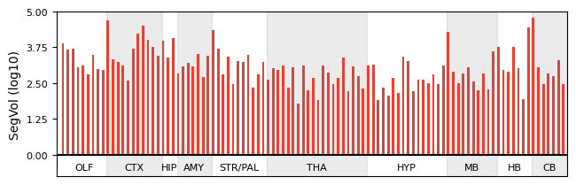

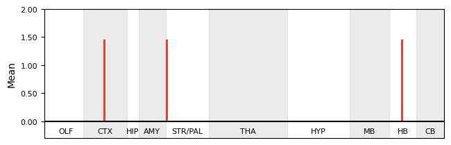

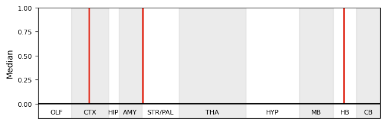

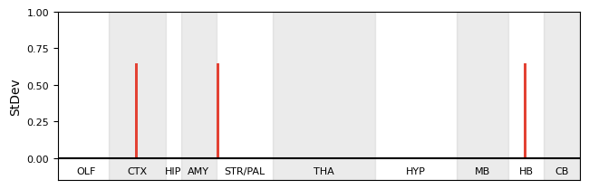

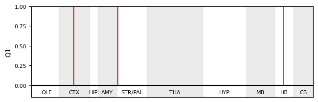

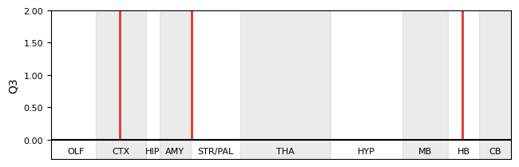

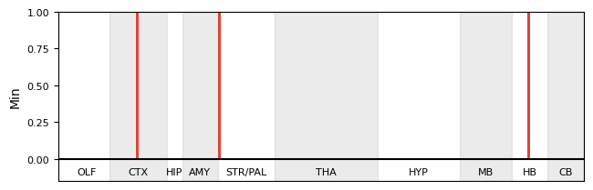

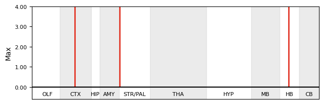

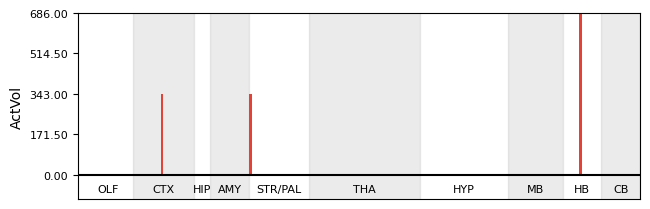

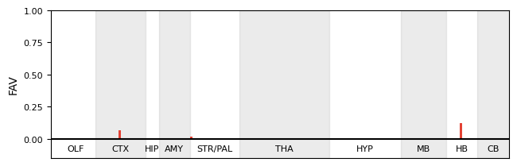

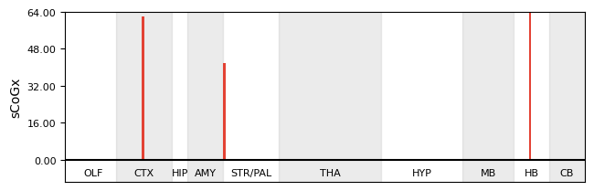

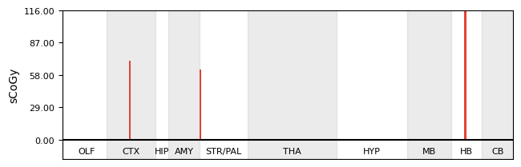

[1 more figures not shown]

```python
# Plot Column Graph Summaries for various metrics
# Define threshold >0 subset for plotting
validation_df_subset = validation_df.loc[validation_df['Threshold'] == 0,]
for val in ("SegVol", "Mean", "Median", "StDev", "Q1", "Q3", "Min", "Max", "ActVol", "FAV", "sCoGx", "sCoGy", "sCoGz"):
    # Define plot names for saving
    plot_name = os.path.join("./examples/validation/OutputData/ColumnGraphs",("Validation_" + val + "_thr0.png"))
    ax = plt(
        seg_df = validation_df_subset,
        seg_rm = seg_to_remove,
        order = "Grouping",
        y = val,
        fill = "Group",
        col_vals = ("#E34234", "#0000FF",
                    "#FFFF00", "#87CEEB"),
        save = True,
        fname = plot_name,
        fig_dims = dim_scale((3.3, 1.1), 2),
        font_scale = 2
        )
```

**Summary:** As observed in the above plots, all segments have been segmented as indicated by the SegVol graph showing the segment volumes, i.e., number of voxels (log10). Segments are ordered to the *InVivo* Atlas convention, by domain and then segment within domain, roughly anterior to posterior and superficial to deep. For instance, from left to right is olfactory regions then cortex, then deeper telencephalon regions, then diencephalon regions, then mes/met/myelencephalon and lastly cerebellum.

Note that the graphs indicate that the correct/expected statistics have been calculated by our segmentation process for the Anterior Cingulate Area (ACA in CTX). Furthermore, all regions without a validation cube (i.e., all other segments) have values of 0 for all segmental measures.

## **Example 2:** Segmentation of Simulated Noise-only (Negatives) Controls

For this example we have a statistical (Cohen's D effect size) map corresponding to a voxel-wise paired t-test that compared a set of simulated images with only voxel-wise noise. The statistical map comparing 'noise-only' simulated data was generated in SPM12 using the optimal smoothing kernel, t-value threshold and cluster extent (see paper for details: n=11; kernel = 150 $\mu m$; T<sub>(10), p<0.05</sub> $\ge$ 1.81; cluster extent $\ge$ 8 voxels). Suprathreshold voxels in this map reflect *False Positives* from dataset noise.

The goal of segmenting this statistical map of false positives is to obtain distributions noise-driven magnitudes of segmental measures to compare against real data. This analysis can be used for selecting a lower bound threshold for various segmentation statistics.

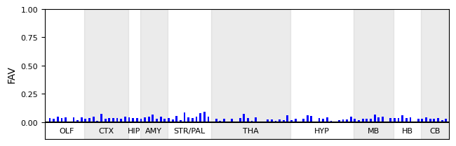

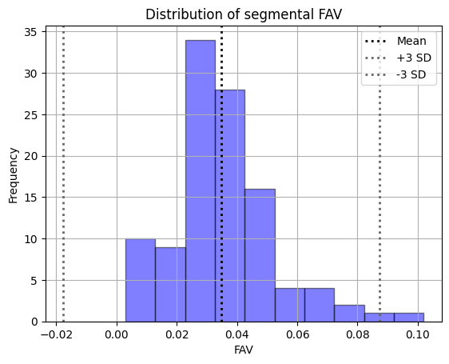

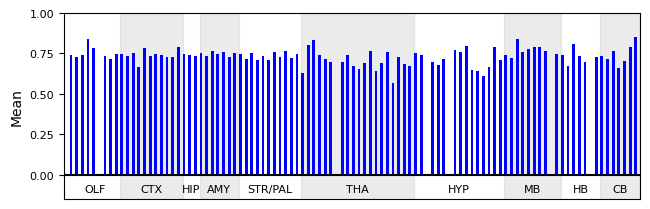

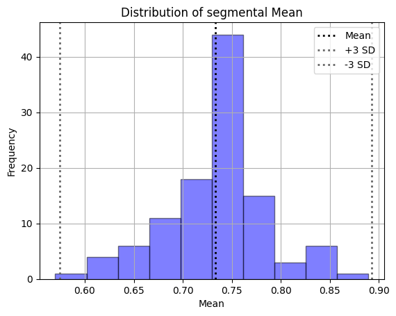

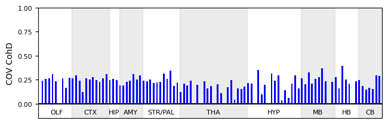

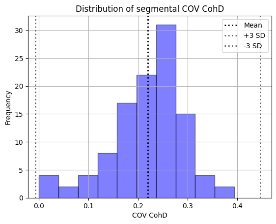

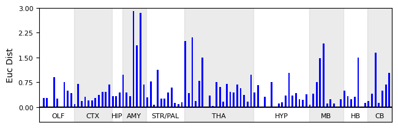

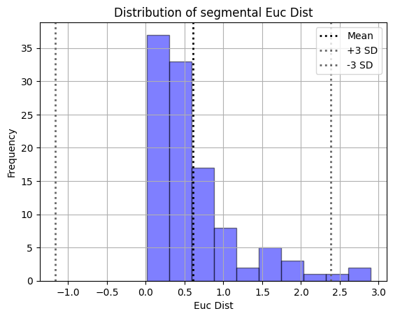

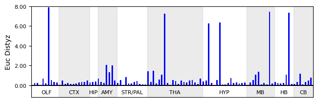

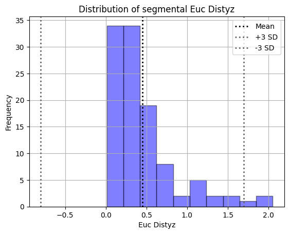

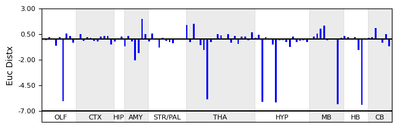

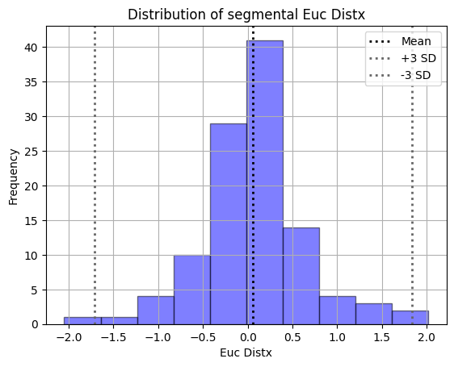

[4 more figures not shown]

```
------ Summary Statistics for Noise Simulation ------
```

Noise Only

|  | count | mean | std | min | 25% | 50% | 75% | max |
| --- | --- | --- | --- | --- | --- | --- | --- | --- |
| Mean | 109.0 | 0.733613 | 0.052938 | 0.569856 | 0.708552 | 0.738703 | 0.756793 | 0.889458 |
| Median | 109.0 | 0.690101 | 0.048431 | 0.566841 | 0.663325 | 0.684431 | 0.714582 | 0.820111 |
| StDev | 109.0 | 0.163978 | 0.062354 | 0.000000 | 0.129650 | 0.174877 | 0.202013 | 0.319602 |
| Q1 | 109.0 | 0.616190 | 0.032280 | 0.557796 | 0.600008 | 0.609053 | 0.624128 | 0.750763 |
| Q3 | 109.0 | 0.799724 | 0.077440 | 0.581917 | 0.759809 | 0.808050 | 0.835186 | 1.016093 |
| Min | 109.0 | 0.558211 | 0.025254 | 0.545736 | 0.548751 | 0.548751 | 0.554781 | 0.717597 |
| Max | 109.0 | 1.357022 | 0.446449 | 0.593977 | 1.055290 | 1.293484 | 1.646252 | 2.592998 |
| ActVol | 109.0 | 140.798165 | 300.803454 | 1.000000 | 16.000000 | 42.000000 | 91.000000 | 1897.000000 |
| FAV | 109.0 | 0.034908 | 0.017508 | 0.003000 | 0.026000 | 0.033000 | 0.043000 | 0.102000 |
| sCoGx | 109.0 | 62.520183 | 6.149072 | 40.170000 | 59.690000 | 62.630000 | 65.300000 | 83.890000 |
| sCoGy | 109.0 | 84.096881 | 25.453175 | 27.830000 | 69.970000 | 84.590000 | 97.030000 | 145.310000 |
| sCoGz | 109.0 | 34.011101 | 12.663835 | 11.090000 | 23.700000 | 35.000000 | 42.900000 | 65.970000 |
| COV CohD | 109.0 | 0.219711 | 0.075744 | 0.000000 | 0.183036 | 0.232759 | 0.262548 | 0.394052 |
| Euc Dist | 109.0 | 0.611647 | 0.591337 | 0.014526 | 0.237457 | 0.424434 | 0.758921 | 2.900166 |
| Euc Distx | 109.0 | 0.061358 | 0.590362 | -2.049000 | -0.218000 | 0.045000 | 0.306000 | 2.018000 |
| Euc Disty | 109.0 | 0.020688 | 0.164220 | -0.377000 | -0.087000 | 0.026000 | 0.102000 | 0.504000 |
| Euc Distz | 109.0 | -0.006459 | 0.150199 | -0.414000 | -0.097000 | -0.013000 | 0.059000 | 0.463000 |

```python
# Load SPM segmentation CSV
noise_df = pd.read_csv("./examples/noise_simulations/OutputData/CSVs/NoiseSegmentationResults.csv", na_values=["", " ", "NA", "-"])

noise_df['Group'] = noise_df['Group'].astype('category')
# Tranform a few variables
## Center of Gravity of Signal from Segmental CoG
noise_df['Euc Dist']  = np.sqrt((noise_df['sCoGx']-noise_df['CoGx'])**2 +
                              (noise_df['sCoGx']-noise_df['CoGx'])**2 +
                              (noise_df['sCoGz']-noise_df['CoGz'])**2) * 0.1
noise_df['Euc Distyz']  = np.sqrt((noise_df['sCoGx']-noise_df['CoGx'])**2 +
                                  (noise_df['sCoGz']-noise_df['CoGz'])**2) * 0.1
noise_df['Euc Distx'] = (noise_df['sCoGx']-noise_df['CoGx']) * 0.1
noise_df['Euc Disty'] = (noise_df['sCoGy']-noise_df['CoGy']) * 0.1
noise_df['Euc Distz'] = (noise_df['sCoGz']-noise_df['CoGz']) * 0.1
# converted to mm
for index, row in noise_df.iterrows():
    if row["sCoGx"] == 0 and row["sCoGy"] == 0 and row["sCoGz"] == 0:
        noise_df.at[index,"Euc Dist"] = 0
## Convert T-value to Cohen's D
n = 11 # number of subjects
for val in ["Mean", "Median", "StDev", "Q1", "Q3", "Min", "Max"]:
    noise_df[val]  = noise_df[val] / np.sqrt(n)

noise_df['COV CohD']   = noise_df['StDev'] / noise_df['Mean']
noise_df_tmp = noise_df.copy()
for val in ("FAV", "Mean", "COV CohD",
            "Euc Dist",'Euc Distyz', "Euc Distx", "Euc Disty", "Euc Distz"):
    # remove spaces in val names
    val2 = val.replace(" ", "-")
    plot_name = os.path.join("./examples/noise_simulations/OutputData/ColumnGraphs",("NoiseOnly_" + val2 + "_optimal.png"))
    ax = plt(
        seg_df = noise_df_tmp,
        seg_rm = seg_to_remove,
        order = "Grouping",
        y = val,
        fill = "Condition",
        col_vals = ("#0000FF", "#87CEEB"),
        save = False,
        fname = plot_name,
        fig_dims = dim_scale((3.3, 1.1), 2),
        font_scale = 2
        )

    # Plot distributions
    fig, ax = mplt.subplots()

    noise_df_tmp2 = noise_df.loc[noise_df["FAV"] > 0]
    noise_df_tmp2[val].hist(bins=10, color="#0000FF", alpha = 0.5, edgecolor='black')
    # 3. Add vertical dotted lines at mean ± 3*std
    mean_val = noise_df_tmp2[val].mean()
    std_val = noise_df_tmp2[val].std()
    mplt.axvline(mean_val, color='black', linestyle='dotted', linewidth=2, label='Mean')
    mplt.axvline(mean_val + 3*std_val, color='0.4', linestyle='dotted', linewidth=2, label='+3 SD')
    mplt.axvline(mean_val - 3*std_val, color='0.4', linestyle='dotted', linewidth=2, label='-3 SD')

    mplt.title(f'Distribution of segmental {val}')
    mplt.xlabel(val)
    mplt.ylabel('Frequency')
    mplt.legend()
    mplt.show()

meanstd_val_df = pd.DataFrame(columns=['Measure', 'Mean', '3SD_lower', '3SD_upper'])
for idx, val in enumerate(["Mean","Median","StDev","Q1","Q3","Min","Max","ActVol","FAV","sCoGx","sCoGy","sCoGz", "COV CohD","Euc Dist", "Euc Distx", "Euc Disty", "Euc Distz"]):
    mean_val = noise_df_tmp2[val].mean()
    std_val = noise_df_tmp2[val].std()
    meanstd_val_df.loc[idx] = [val, mean_val,
                               mean_val - 3*std_val,
                               mean_val + 3*std_val]

# To display this raw string as a table in Jupyter:
noisenegtb = noise_df_tmp2.loc[noise_df_tmp2['Group'] == "Negative",["Group","Mean","Median","StDev","Q1","Q3","Min","Max","ActVol","FAV","sCoGx","sCoGy","sCoGz", "COV CohD","Euc Dist", "Euc Distx", "Euc Disty", "Euc Distz"]].describe().T
html_neg_tb = "<h3>Noise Only</h3>" + noisenegtb.to_html(index=True)

print("------ Summary Statistics for Noise Simulation ------")
HTML(html_neg_tb)
```

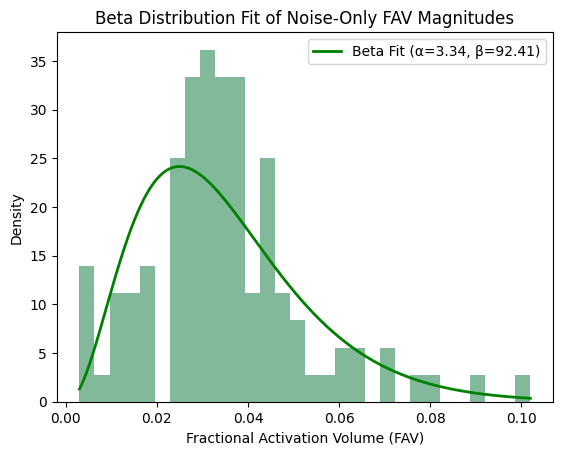

```
------ Fitting a Beta Distribution to Segmental FAV from Noise Only Simulations  ------
Fitted Alpha: 3.3402
Fitted Beta: 92.4097
Beta-based FAV Threshold (99.9th percentile): 0.1157
```

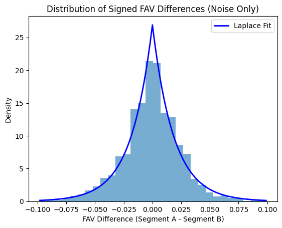

```
------ Fitting a Laplace Distribution to Differences in Segmental FAV from Noise Only Simulations  ------
Fitted Location: 0.0000
Fitted Scale: 0.0186
Laplace-based FAV Difference Threshold (99.9th percentile): +/- 0.1283
```

```python
# Beta distribution fit for FAV in Noise Only SPM comparison

from scipy.stats import beta
from scipy.stats import norm

noise_df_tmp3 = noise_df_tmp2["FAV"].values



a_fit, b_fit, loc_fit, scale_fit = beta.fit(noise_df_tmp3, floc=0, fscale=1)


mplt.hist(noise_df_tmp3, bins=30, density=True, alpha=0.6, color = "seagreen")
x = np.linspace(min(noise_df_tmp3), max(noise_df_tmp3), 1000)
y = beta.pdf(x, a_fit, b_fit, loc_fit, scale_fit)
mplt.plot(x, y, 'g-', lw=2, label=f'Beta Fit (α={a_fit:.2f}, β={b_fit:.2f})')
mplt.title('Beta Distribution Fit of Noise-Only FAV Magnitudes')
mplt.xlabel('Fractional Activation Volume (FAV)')
mplt.ylabel('Density')
mplt.legend()
mplt.show()

num_sd = 3
pct = 1 - norm.sf(num_sd)
threshold = beta.ppf(pct, a_fit, b_fit, loc=0, scale=1)

print("------ Fitting a Beta Distribution to Segmental FAV from Noise Only Simulations  ------")
print(f"Fitted Alpha: {a_fit:.4f}")
print(f"Fitted Beta: {b_fit:.4f}")
print(f"Beta-based FAV Threshold ({round(100*pct,1)}th percentile): {threshold:.4f}")

import itertools
# Calculate all pairwise differences in your noise-only segments
diffs = [(a - b) for a, b in itertools.combinations(noise_df_tmp3, 2)]


from scipy.stats import laplace
loc_lap, scale_lap = laplace.fit(diffs)

mplt.hist(diffs, bins=30, density=True, alpha=0.6)
x = np.linspace(min(diffs), max(diffs), 1000)
mplt.plot(x, laplace.pdf(x, loc_lap, scale_lap), 'b-', lw=2, label='Laplace Fit')
mplt.title('Distribution of Signed FAV Differences (Noise Only)')
mplt.xlabel('FAV Difference (Segment A - Segment B)')
mplt.ylabel('Density')
mplt.legend()
mplt.show()

# For a two-tailed 99.7% confidence interval (0.15% in each tail)
upper_diff_threshold = laplace.ppf(0.9995, loc_lap, scale_lap)
lower_diff_threshold = laplace.ppf(0.0005, loc_lap, scale_lap)
print("------ Fitting a Laplace Distribution to Differences in Segmental FAV from Noise Only Simulations  ------")
print(f"Fitted Location: {loc_lap:.4f}")
print(f"Fitted Scale: {scale_lap:.4f}")
print(f"Laplace-based FAV Difference Threshold (99.9th percentile): +/- {upper_diff_threshold:.4f}")
```